# proportion_R Package

Subbiah

### proportion: A comprehensive R package for inference on single Binomial proportion and Bayesian computations

Extensive statistical practice has shown the importance and relevance of the inferential problem of estimating probability parameter in a binomial experiment. Specifically, issues of competing intervals from using frequentist, Bayesian, and Bootstrap methods engage many research activities.

To address such a wider research objectives, a ubiquitous requirement is computational environment. In this endeavor, this package in the free R environment aims in pooling widely applied methods, their performance metrics with essential variations.

A wide range of functions helps the users of different level to estimate, evaluate, summarize in numerical and graphical forms for various measures in frequentist and Bayesian paradigms.

#### Notations Used in the package

1. x: Number of successes
2. n: Number of trials
3. $\alpha$: Level of significance
4. e: Exact method indicator in [0, 1] {1: Clopper Pearson, 0.5: Mid P}
5. a and b: Beta parameters for hypothetical parameter generation; Prior parameters in Bayesian predictive models
6. t1 and t2: Limits for tolerance (within which CP lies)
7. $\pi$: Population parameter
8. f: Failure limit
9. h: Constant used in adjustment methods
10. c: Constant used in continuity corrected methods
11. a1,a2: Prior parameters in Bayesian estimation procedures
12. LL, UL: Lower and Upper limits for the intervals due to any other methods
13. s: Number of simulations
14. hp: Hypothetical parameter values
15. sL, sU: Lower and Upper specification for hyper prior in Empirical Bayesian (EB) approach
16. m, ynew: Number of trials and number of successes in Bayesian predictive models
17. th0, th1, th2: Parameter values in the models M0, M1, M2 of Bayes factor
18. aj, bj: Prior parameters in the models Mj (j = 0, 1, 2) of Bayes factor
19. th: Parameter value in Bayesian posterior probabilities

Following figure presents Work flow for the **R package proportion** that deals with various computational tools for the inferential procedures involving single binomial proportion parameter

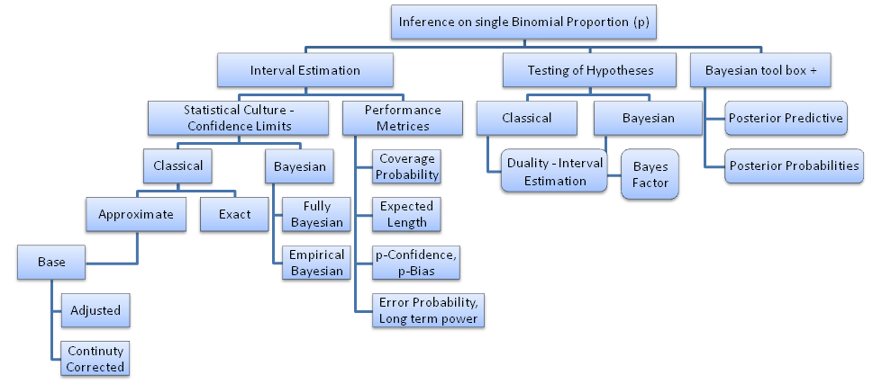